# Heart Attack Risk Prediction - Machine Learning Project

## DTSC-691: Applied Data Science & Analytics

## Name: Edwin Mutevane

### Load the required libraries

```python
import pandas as pd
import numpy as np
import matplotlib.pyplot as plt
import seaborn as sns
import shap
import janitor
import warnings
warnings.filterwarnings('ignore')
```

### Load dataset

```python
df = pd.read_csv('Heart_Attack_Risk_Levels_Dataset.csv').clean_names()
```

### Inspect the dataset - first and last few observations of the dataset

```python
df.head(5)
```

|  | age | gender | heart_rate | systolic_blood_pressure | diastolic_blood_pressure | blood_sugar | ck_mb | troponin | result | risk_level | recommendation |
| --- | --- | --- | --- | --- | --- | --- | --- | --- | --- | --- | --- |
| 0 | 63 | 1 | 66 | 160 | 83 | 160.0 | 1.80 | 0.012 | negative | Moderate | Monitor closely and consult doctor |
| 1 | 20 | 1 | 94 | 98 | 46 | 296.0 | 6.75 | 1.060 | positive | High | Immediate medical attention |
| 2 | 56 | 1 | 64 | 160 | 77 | 270.0 | 1.99 | 0.003 | negative | Moderate | Monitor closely and consult doctor |
| 3 | 66 | 1 | 70 | 120 | 55 | 270.0 | 13.87 | 0.122 | positive | High | Immediate medical attention |
| 4 | 54 | 1 | 64 | 112 | 65 | 300.0 | 1.08 | 0.003 | negative | Moderate | Monitor closely and consult doctor |

```python
df.tail(5)
```

|  | age | gender | heart_rate | systolic_blood_pressure | diastolic_blood_pressure | blood_sugar | ck_mb | troponin | result | risk_level | recommendation |
| --- | --- | --- | --- | --- | --- | --- | --- | --- | --- | --- | --- |
| 1314 | 44 | 1 | 94 | 122 | 67 | 204.0 | 1.63 | 0.006 | negative | Moderate | Monitor closely and consult doctor |
| 1315 | 66 | 1 | 84 | 125 | 55 | 149.0 | 1.33 | 0.172 | positive | High | Immediate medical attention |
| 1316 | 45 | 1 | 85 | 168 | 104 | 96.0 | 1.24 | 4.250 | positive | High | Immediate medical attention |
| 1317 | 54 | 1 | 58 | 117 | 68 | 443.0 | 5.80 | 0.359 | positive | High | Immediate medical attention |
| 1318 | 51 | 1 | 94 | 157 | 79 | 134.0 | 50.89 | 1.770 | positive | High | Immediate medical attention |

### Data Types Check

```python
df.dtypes
```

```
age                           int64
gender                        int64
heart_rate                    int64
systolic_blood_pressure       int64
diastolic_blood_pressure      int64
blood_sugar                 float64
ck_mb                       float64
troponin                    float64
result                       object
risk_level                   object
recommendation               object
dtype: object
```

### Structure of the dataset

```python
df.info()
```

```
<class 'pandas.core.frame.DataFrame'>
RangeIndex: 1319 entries, 0 to 1318
Data columns (total 11 columns):
 #   Column                    Non-Null Count  Dtype
---  ------                    --------------  -----
 0   age                       1319 non-null   int64
 1   gender                    1319 non-null   int64
 2   heart_rate                1319 non-null   int64
 3   systolic_blood_pressure   1319 non-null   int64
 4   diastolic_blood_pressure  1319 non-null   int64
 5   blood_sugar               1319 non-null   float64
 6   ck_mb                     1319 non-null   float64
 7   troponin                  1319 non-null   float64
 8   result                    1319 non-null   object
 9   risk_level                1319 non-null   object
 10  recommendation            1319 non-null   object
dtypes: float64(3), int64(5), object(3)
memory usage: 113.5+ KB
```

### Unique Values and Cardinality

```python
df.nunique()
```

```
age                          75
gender                        2
heart_rate                   79
systolic_blood_pressure     116
diastolic_blood_pressure     73
blood_sugar                 244
ck_mb                       700
troponin                    352
result                        2
risk_level                    3
recommendation                3
dtype: int64
```

### Checking for missing values

```python
df.isnull().sum()
```

```
age                         0
gender                      0
heart_rate                  0
systolic_blood_pressure     0
diastolic_blood_pressure    0
blood_sugar                 0
ck_mb                       0
troponin                    0
result                      0
risk_level                  0
recommendation              0
dtype: int64
```

### Data type distribution

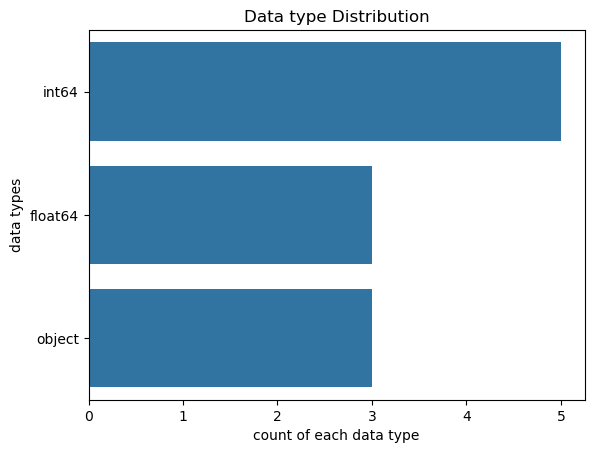

```python
sns.countplot(y=df.dtypes ,data=df)
plt.title('Data type Distribution')
plt.xlabel('count of each data type')
plt.ylabel('data types')
plt.show()
```

### Check for duplicates

```python
df.duplicated().sum()
```

```
0
```

### Data Cleaning & Preprocessing

#### Drop unwanted columns

```python
df = df.drop(columns=['risk_level', 'recommendation'])
```

### Label encoding of the target variable

```python
## Initialize LabelEncoder
from sklearn.preprocessing import LabelEncoder
label = LabelEncoder()

# Apply label encoding to the 'Result' column
df['result'] = label.fit_transform(df['result'])
df['result']
```

```
0       0
1       1
2       0
3       1
4       0
       ..
1314    0
1315    1
1316    1
1317    1
1318    1
Name: result, Length: 1319, dtype: int32
```

## Exploratory Data Analysis

### Summary Statistics

```python
df.describe()
```

|  | age | gender | heart_rate | systolic_blood_pressure | diastolic_blood_pressure | blood_sugar | ck_mb | troponin | result |
| --- | --- | --- | --- | --- | --- | --- | --- | --- | --- |
| count | 1319.000000 | 1319.000000 | 1319.000000 | 1319.000000 | 1319.000000 | 1319.000000 | 1319.000000 | 1319.000000 | 1319.000000 |
| mean | 56.193328 | 0.659591 | 78.336619 | 127.170584 | 72.269143 | 146.634344 | 15.274306 | 0.360942 | 0.614102 |
| std | 13.638173 | 0.474027 | 51.630270 | 26.122720 | 14.033924 | 74.923045 | 46.327083 | 1.154568 | 0.486991 |
| min | 14.000000 | 0.000000 | 20.000000 | 42.000000 | 38.000000 | 35.000000 | 0.321000 | 0.001000 | 0.000000 |
| 25% | 47.000000 | 0.000000 | 64.000000 | 110.000000 | 62.000000 | 98.000000 | 1.655000 | 0.006000 | 0.000000 |
| 50% | 58.000000 | 1.000000 | 74.000000 | 124.000000 | 72.000000 | 116.000000 | 2.850000 | 0.014000 | 1.000000 |
| 75% | 65.000000 | 1.000000 | 85.000000 | 143.000000 | 81.000000 | 169.500000 | 5.805000 | 0.085500 | 1.000000 |
| max | 103.000000 | 1.000000 | 1111.000000 | 223.000000 | 154.000000 | 541.000000 | 300.000000 | 10.300000 | 1.000000 |

### Distribution of Numerical Variables

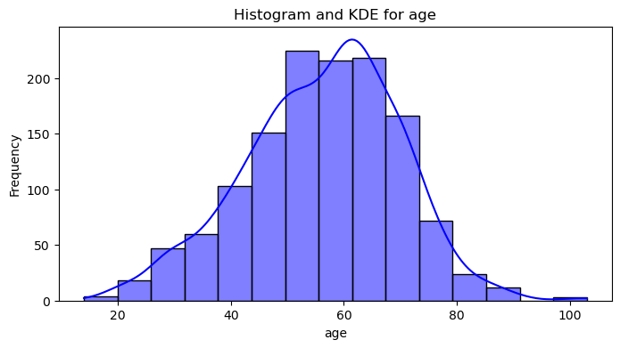

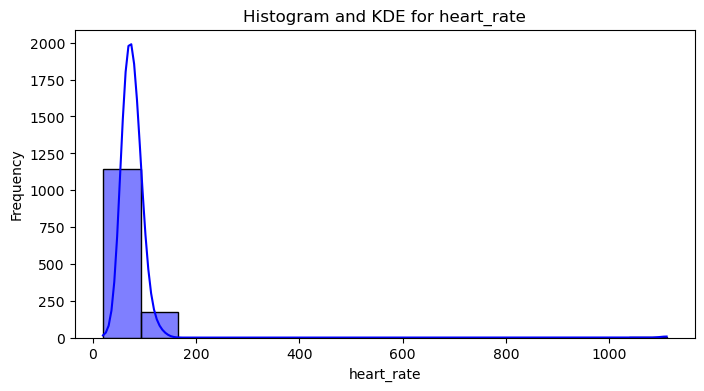

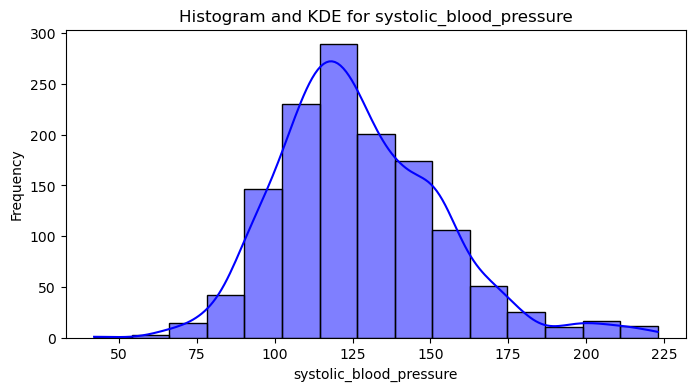

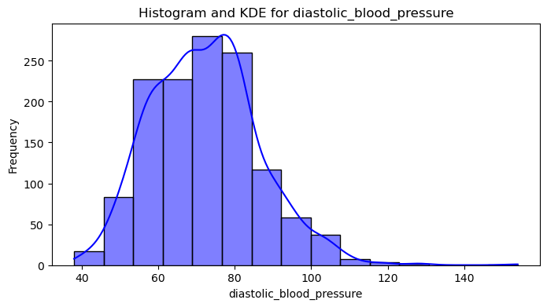

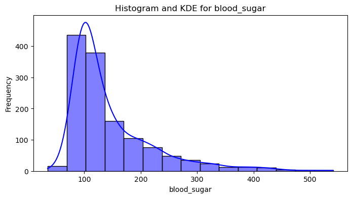

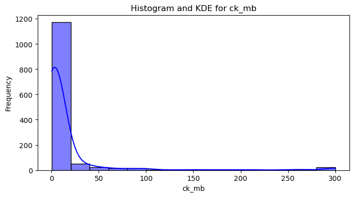

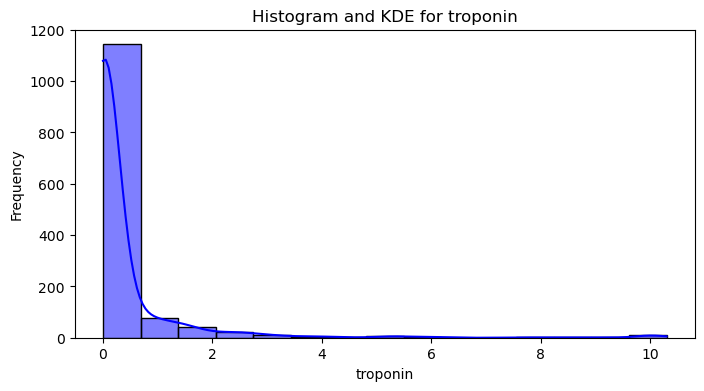

```python
numeric_col = df.drop(columns = ["result", "gender"])
for col in numeric_col:
    plt.figure(figsize = (8, 4))
    sns.histplot(df[col], kde = True, bins = 15, color = "blue")
    plt.title(f'Histogram and KDE for {col}')
    plt.xlabel(col)
    plt.ylabel("Frequency")
    plt.show()
```

### Boxplots to Detect Outliers

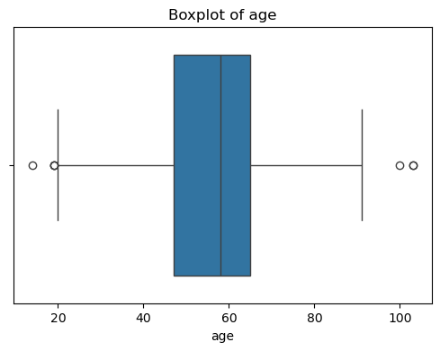

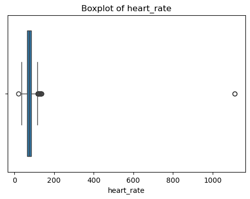

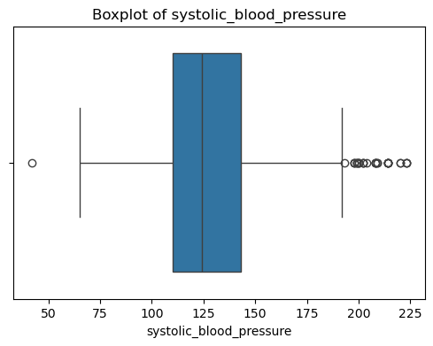

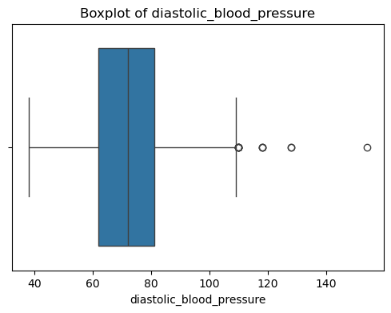

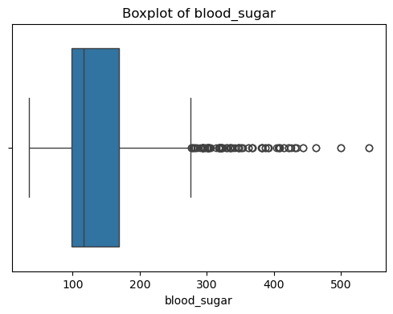

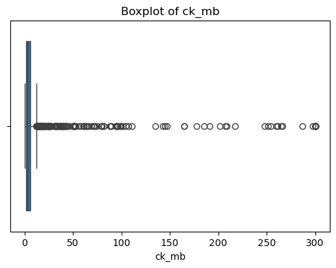

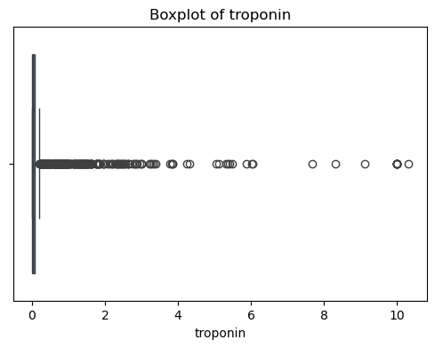

```python
for col in numeric_col:
    plt.figure(figsize=(6, 4))
    sns.boxplot(x=df[col])
    plt.title(f'Boxplot of {col}')
    plt.show()
```

### Gender Distribution

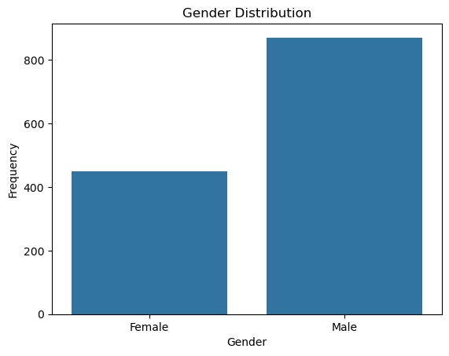

```python
sns.countplot(x="gender", data=df)
plt.title('Gender Distribution')
plt.ylabel("Frequency")
plt.xlabel("Gender")
plt.xticks([0, 1], labels=["Female", "Male"])
plt.show()
```

### Distribution of the target variable

```python
df["result"].value_counts()
```

```
result
1    810
0    509
Name: count, dtype: int64
```

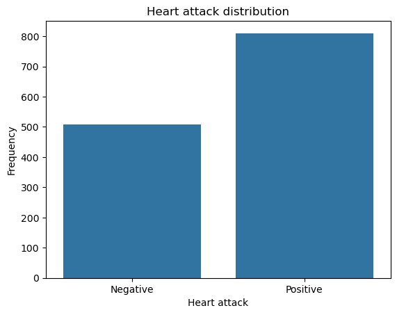

```python
## Class Distribution
sns.countplot(x="result", data=df)
plt.title('Heart attack distribution')
plt.ylabel("Frequency")
plt.xticks([0, 1], labels=["Negative", "Positive"])
plt.xlabel("Heart attack")
plt.show()
```

### Correlation Matrix

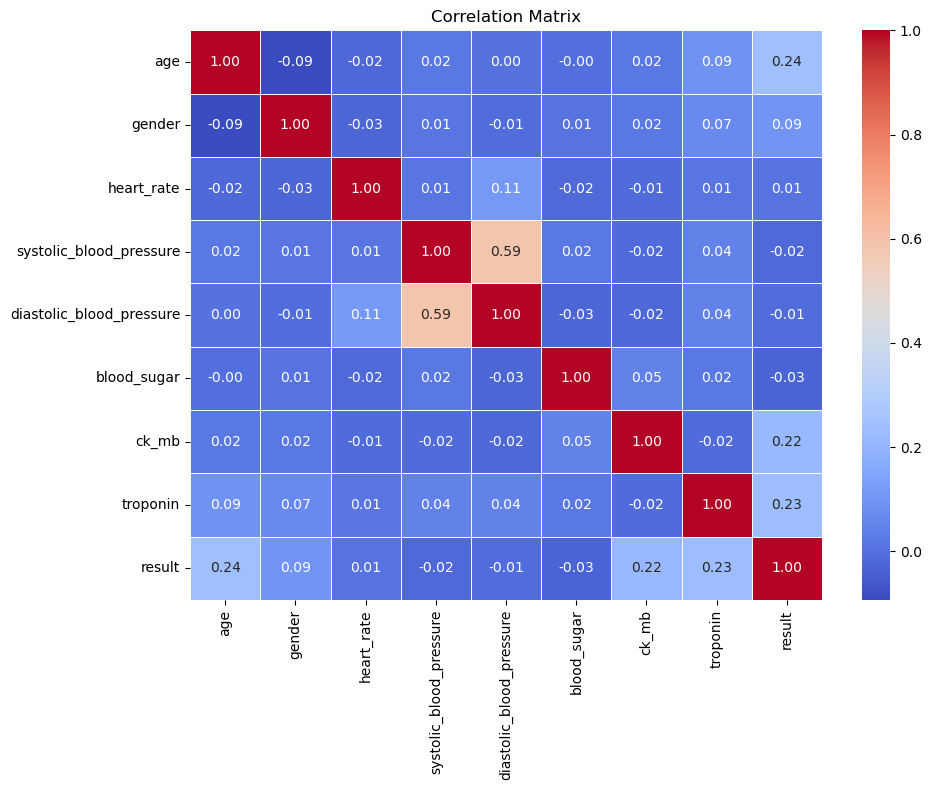

```python
corr_matrix = df.corr()
plt.figure(figsize=(10, 8))
sns.heatmap(corr_matrix, annot=True, cmap='coolwarm', fmt=".2f", linewidths=0.5)

plt.title("Correlation Matrix")
plt.tight_layout()
plt.show()
```

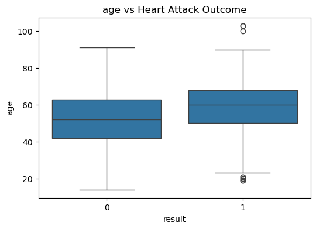

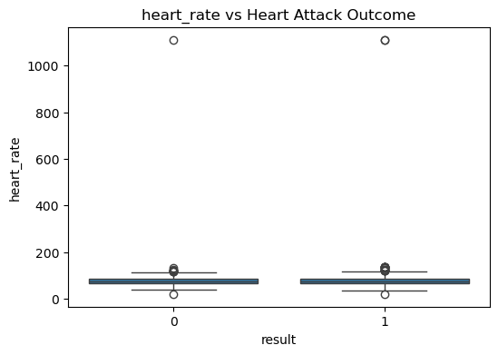

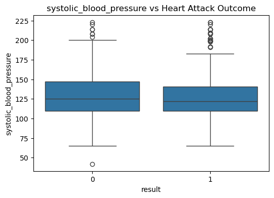

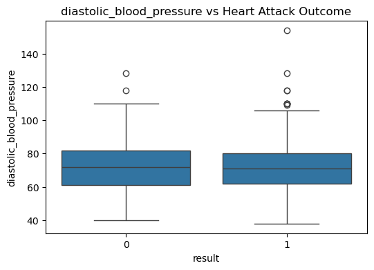

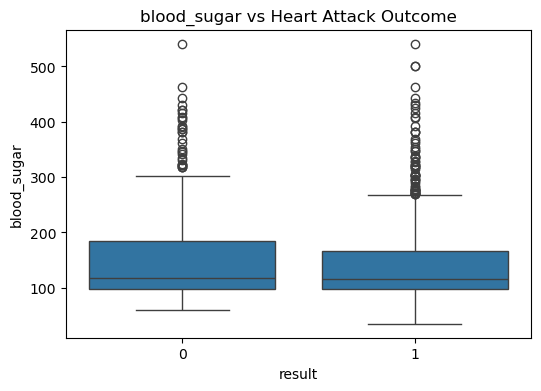

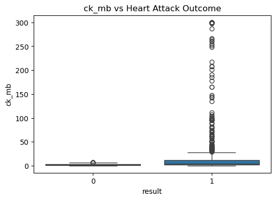

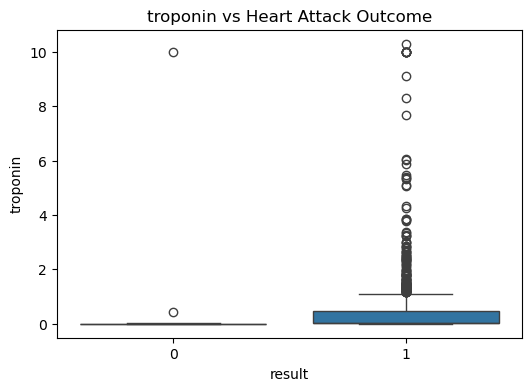

```python
for col in numeric_col:
    plt.figure(figsize=(6, 4))
    sns.boxplot(x='result', y=col, data=df)
    plt.title(f'{col} vs Heart Attack Outcome')
    plt.show()
```

### Bivariate Relationships (Scatterplots)

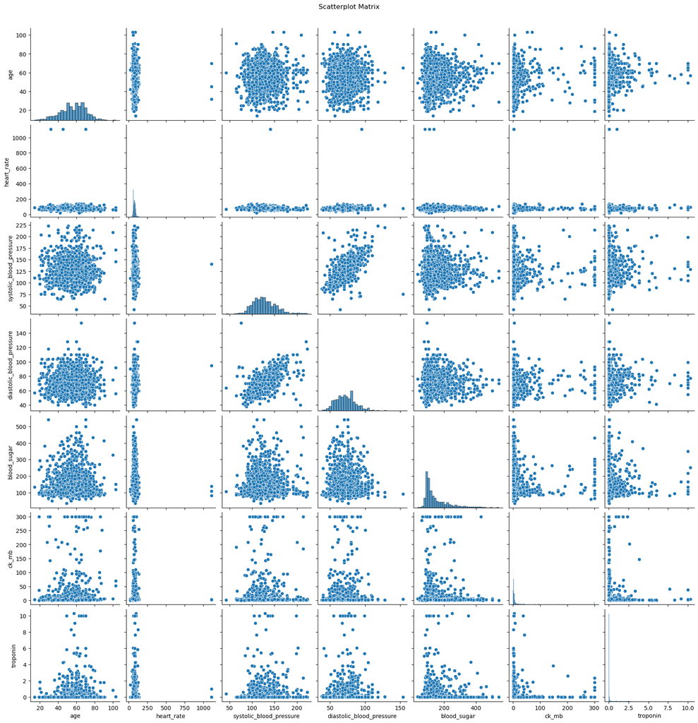

```python
sns.pairplot(numeric_col)
plt.suptitle("Scatterplot Matrix", y=1.02)
plt.show()
```

This scatterplot matrix illustrates pairwise relationships among clinical variables related to heart health. A strong positive correlation is observed between systolic and diastolic blood pressure, as expected. Age shows a moderate spread across most variables, with a visible increase in CK-MB and troponin levels among certain older individuals. CK-MB and troponin are notably clustered and skewed, indicating their potential diagnostic value in detecting cardiac events. In contrast, heart rate and blood sugar show little to no clear relationship with other variables.

### Cross Tabulation and Stacked Bar Charts

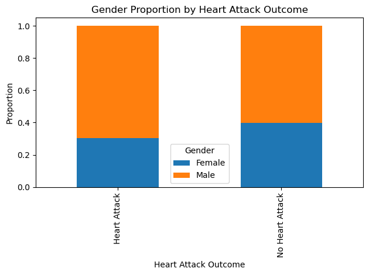

```python
# Create a copy of your DataFrame
df_plot = df.copy()

# Rename values for clarity
df_plot['result'] = df_plot['result'].replace({1 : 'Heart Attack', 0 : 'No Heart Attack'})
df_plot['gender'] = df_plot['gender'].replace({0: 'Female', 1: 'Male'})

# Create normalized crosstab
crosstab = pd.crosstab(df_plot['result'], df_plot['gender'], normalize='index')

# Plot
crosstab.plot(kind='bar', stacked=True)

# Set labels and title
plt.title("Gender Proportion by Heart Attack Outcome")
plt.ylabel("Proportion")
plt.xlabel("Heart Attack Outcome")
plt.legend(title="Gender")
plt.tight_layout()
plt.show()
```

### Chi-square Tests for Categorical Associations

```python
# Load required module
from scipy.stats import chi2_contingency

# Create contingency table
table = pd.crosstab(df['gender'], df['result'])

# Perform Chi-square test
chi2, p, dof, ex = chi2_contingency(table)

# Print result
print(f"Chi-square test between Gender and Heart Attack Outcome: p-value = {p:.4f}")
```

```
Chi-square test between Gender and Heart Attack Outcome: p-value = 0.0008
```

The Chi-square test revealed a statistically significant association between gender and heart attack outcome (p = 0.0008), suggesting that gender may influence the likelihood of experiencing a heart attack.

### T-tests (Numeric vs. Categorical)

```python
# Load required module
from scipy.stats import ttest_ind

# Get all numeric columns
numeric_col = df.drop(columns = ["result", "gender"])

# Split the dataset into two groups based on 'Result'
group1 = df[df['result'] == 1]
group2 = df[df['result'] == 0]

## Perform independent t-test for each numeric column
ttest_results = []
for col in numeric_col:
    t_stat, p_val = ttest_ind(group1[col], group2[col], equal_var=False)  # Welch's t-test
    ttest_results.append((col, p_val))

ttest_results
```

```
[('age', 6.641901387727019e-18),
 ('heart_rate', 0.7969260853088802),
 ('systolic_blood_pressure', 0.45574825157843557),
 ('diastolic_blood_pressure', 0.7279941855792156),
 ('blood_sugar', 0.23842221940845199),
 ('ck_mb', 4.140673523845025e-23),
 ('troponin', 7.200656876108758e-24)]
```

T-test results indicate that age, CK-MB, and troponin levels are statistically significant (p < 0.05), suggesting they are strongly associated with the outcome under investigation. In contrast, heart rate, blood pressure (both systolic and diastolic), and blood sugar levels did not show statistically significant differences between groups.

### Pre processing

#### Defining the X and y features

```python
X = df.drop(columns = ["result"])
y = df["result"]
```

#### Splitting data into training and test set

```python
# Load the required module
from sklearn.model_selection import train_test_split

# Split the data
X_train, X_test, y_train, y_test = train_test_split(X, y, stratify = y, random_state = 42, test_size = 0.2)
```

```python
print("X_train shape:", X_train.shape)
print("X_test shape:", X_test.shape)
print("y_train shape:", y_train.shape)
print("y_test shape:", y_test.shape)
```

```
X_train shape: (1055, 8)
X_test shape: (264, 8)
y_train shape: (1055,)
y_test shape: (264,)
```

#### Feature Scaling/Standardization

```python
# Load the required module
from sklearn.preprocessing import MinMaxScaler

# Initialize the scaler
scaler = MinMaxScaler()

# Fit the scaler
X_train = scaler.fit_transform(X_train)
X_test = scaler.transform(X_test)
```

### 1. Logistic Regression

```
Classification Report:
               precision    recall  f1-score   support

           0       0.71      0.43      0.54       102
           1       0.71      0.89      0.79       162

    accuracy                           0.71       264
   macro avg       0.71      0.66      0.66       264
weighted avg       0.71      0.71      0.69       264

F1 Score: 0.6638970785312248
Precision: 0.7112743532417758
Recall: 0.6601307189542484
Accuracy: 0.7121212121212122
```

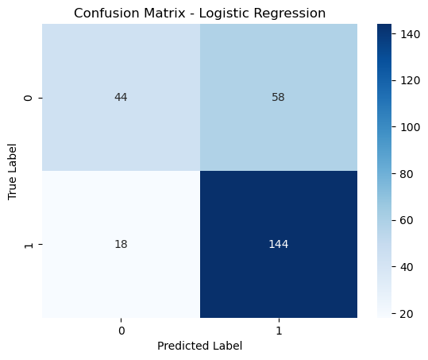

```python
## Load required modules
from sklearn.linear_model import LogisticRegression
from sklearn.metrics import classification_report, confusion_matrix, f1_score, precision_score, recall_score, accuracy_score
import matplotlib.pyplot as plt
import seaborn as sns

## Initialize the model with better configuration
log = LogisticRegression(random_state=42, solver='lbfgs', max_iter=1000)

## Fit the model
log.fit(X_train, y_train)

## Make predictions
log_pred = log.predict(X_test)
log_score = accuracy_score(y_test, log_pred)

## Evaluate performance
print("Classification Report:\n", classification_report(y_test, log_pred))
print("F1 Score:", f1_score(y_test, log_pred, average='macro'))
print("Precision:", precision_score(y_test, log_pred, average='macro'))
print("Recall:", recall_score(y_test, log_pred, average='macro'))
print("Accuracy:", accuracy_score(y_test, log_pred))

## Confusion Matrix
cm = confusion_matrix(y_test, log_pred)
sns.heatmap(cm, annot=True, fmt='d', cmap='Blues')
plt.title("Confusion Matrix - Logistic Regression")
plt.xlabel("Predicted Label")
plt.ylabel("True Label")
plt.show()
```

### Decision Trees

```python
# Load required modules
from sklearn.tree import DecisionTreeClassifier
from sklearn.model_selection import GridSearchCV
from sklearn.metrics import classification_report, f1_score, precision_score, recall_score, accuracy_score
import matplotlib.pyplot as plt

# Initialize model
dt = DecisionTreeClassifier(random_state=42)

# Define a more efficient parameter grid
parameters = {
    'criterion': ['gini', 'entropy'],
    'max_depth': [5, 10, 15, 20, None],
    'min_samples_leaf': [1, 2, 4],
    'min_samples_split': [2, 5, 10],
    'splitter': ['best']
}

# Grid Search
grid_search_dt = GridSearchCV(dt, parameters, cv=5, n_jobs=-1, verbose=1, scoring='f1_macro')
grid_search_dt.fit(X_train, y_train)

# Best model prediction
dt_pred = grid_search_dt.predict(X_test)
dt_score = accuracy_score(y_test, dt_pred)

# Evaluation
print("Best Parameters Found:", grid_search_dt.best_params_)
print("Classification Report:\n", classification_report(y_test, dt_pred))
print("F1 Score:", f1_score(y_test, dt_pred, average='macro'))
print("Precision:", precision_score(y_test, dt_pred, average='macro'))
print("Recall:", recall_score(y_test, dt_pred, average='macro'))
print("Accuracy:", accuracy_score(y_test, dt_pred))
```

```
Fitting 5 folds for each of 90 candidates, totalling 450 fits
Best Parameters Found: {'criterion': 'gini', 'max_depth': 5, 'min_samples_leaf': 1, 'min_samples_split': 10, 'splitter': 'best'}
Classification Report:
               precision    recall  f1-score   support

           0       0.98      0.97      0.98       102
           1       0.98      0.99      0.98       162

    accuracy                           0.98       264
   macro avg       0.98      0.98      0.98       264
weighted avg       0.98      0.98      0.98       264

F1 Score: 0.9799924213717317
Precision: 0.9808965559132601
Recall: 0.979121278140886
Accuracy: 0.9810606060606061
```

### 2. Random Forest

```
Fitting 5 folds for each of 20 candidates, totalling 100 fits
Best Parameters: {'n_estimators': 300, 'min_samples_split': 5, 'min_samples_leaf': 2, 'max_features': 'sqrt', 'max_depth': 20, 'bootstrap': True}
Best Cross-Validated F1 Score: 0.9870532516874215

 Classification Report:
               precision    recall  f1-score   support

           0       0.97      0.98      0.98       102
           1       0.99      0.98      0.98       162

    accuracy                           0.98       264
   macro avg       0.98      0.98      0.98       264
weighted avg       0.98      0.98      0.98       264

Accuracy Score: 0.9810606060606061
F1 Score: 0.980064939968285
Precision: 0.9792257130796599
Recall: 0.9809368191721133
```

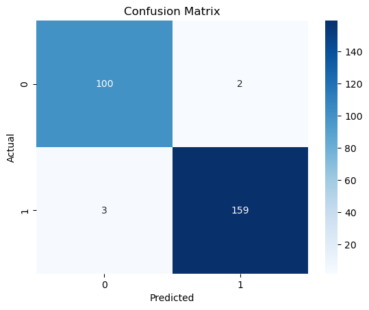

```python
## Import libraries
from sklearn.ensemble import RandomForestClassifier
from sklearn.model_selection import RandomizedSearchCV, RepeatedStratifiedKFold
from sklearn.metrics import classification_report, confusion_matrix, accuracy_score, f1_score, precision_score, recall_score
import seaborn as sns
import matplotlib.pyplot as plt

## Define your model
rf = RandomForestClassifier(class_weight='balanced', random_state=42)

## Define a reduced hyperparameter grid
param_dist = {
    'n_estimators': [100, 300, 500, 800],
    'max_features': ['sqrt', 'log2'],
    'max_depth': [10, 20, None],
    'min_samples_split': [2, 5],
    'min_samples_leaf': [1, 2],
    'bootstrap': [True, False]
}

## Cross-validation strategy
cv = RepeatedStratifiedKFold(n_splits=5, n_repeats=1, random_state=42)

## Use RandomizedSearchCV for efficiency
random_search = RandomizedSearchCV(
    estimator=rf,
    param_distributions=param_dist,
    n_iter=20,  # Try only 20 random combinations
    cv=cv,
    scoring='f1_macro',  # Better than accuracy for imbalanced data
    n_jobs=-1,
    verbose=2,
    random_state=42
)

## Fit the model
best_model = random_search.fit(X_train, y_train)

## Make predictions
rf_pred = best_model.predict(X_test)
rf_score = accuracy_score(y_test, rf_pred)

## Evaluate performance
print("Best Parameters:", random_search.best_params_)
print("Best Cross-Validated F1 Score:", random_search.best_score_)
print("\n Classification Report:\n", classification_report(y_test, rf_pred))
print("Accuracy Score:", accuracy_score(y_test, rf_pred))
print("F1 Score:", f1_score(y_test, rf_pred, average='macro'))
print("Precision:", precision_score(y_test, rf_pred, average='macro'))
print("Recall:", recall_score(y_test, rf_pred, average='macro'))

## Plot the confusion matrix
cm = confusion_matrix(y_test, rf_pred)
sns.heatmap(cm, annot=True, fmt='d', cmap='Blues')
plt.title('Confusion Matrix')
plt.xlabel('Predicted')
plt.ylabel('Actual')
plt.show()
```

### Support Vector Machines

```
Fitting 10 folds for each of 20 candidates, totalling 200 fits
Best Parameters: {'shrinking': False, 'kernel': 'poly', 'gamma': 'scale', 'degree': 3, 'coef0': 0.0, 'C': 10}
Accuracy: 0.7878787878787878
F1 Score (macro): 0.7823706059000176
Precision (macro): 0.7798611111111111
Recall (macro): 0.7926652142338417

 Classification Report:
               precision    recall  f1-score   support

           0       0.69      0.81      0.75       102
           1       0.87      0.77      0.82       162

    accuracy                           0.79       264
   macro avg       0.78      0.79      0.78       264
weighted avg       0.80      0.79      0.79       264
```

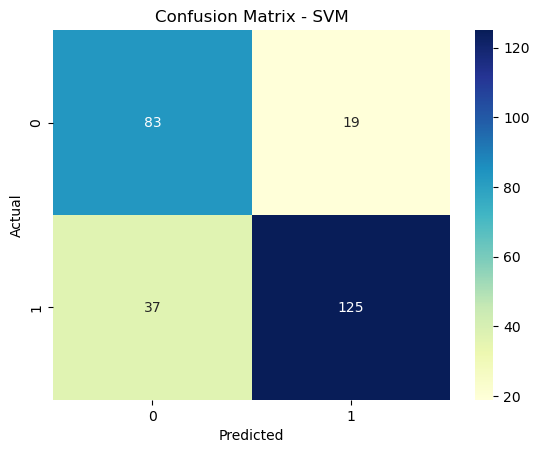

```python
## Import required libraries
from sklearn.svm import SVC
from sklearn.model_selection import RandomizedSearchCV, RepeatedStratifiedKFold
from sklearn.metrics import (classification_report, confusion_matrix,
                             f1_score, precision_score, recall_score, accuracy_score)

## Define CV strategy
cv = RepeatedStratifiedKFold(n_splits=5, n_repeats=2, random_state=42)

## Common SVM model with probability enabled
svm = SVC(probability=True, random_state=42)

## Define separate hyperparameter grids
# RBF Kernel
param_grid_rbf = {
    'kernel': ['rbf'],
    'C': [0.1, 1, 10],
    'gamma': ['scale', 'auto'],
    'shrinking': [True, False]
}

# Poly Kernel
param_grid_poly = {
    'kernel': ['poly'],
    'C': [0.1, 1, 10],
    'gamma': ['scale', 'auto'],
    'degree': [2, 3],
    'coef0': [0.0, 0.5],
    'shrinking': [True, False]
}

# Sigmoid Kernel
param_grid_sigmoid = {
    'kernel': ['sigmoid'],
    'C': [0.1, 1, 10],
    'gamma': ['scale', 'auto'],
    'coef0': [0.0, 0.5],
    'shrinking': [True, False]
}

## Combine the grids
param_grid_combined = [
    param_grid_rbf,
    param_grid_poly,
    param_grid_sigmoid
]

## Use RandomizedSearchCV
random_search = RandomizedSearchCV(
    estimator=svm,
    param_distributions=param_grid_combined,
    n_iter=20,  # 20 random combinations
    scoring='f1_macro',
    n_jobs=-1,
    cv=cv,
    verbose=2,
    random_state=42
)

## Train the model
best_model = random_search.fit(X_train, y_train)

## Make predictions
svm_pred = best_model.predict(X_test)
svm_score = accuracy_score(y_test, svm_pred)

## Evaluate performance
print("Best Parameters:", best_model.best_params_)
print("Accuracy:", accuracy_score(y_test, svm_pred))
print("F1 Score (macro):", f1_score(y_test, svm_pred, average='macro'))
print("Precision (macro):", precision_score(y_test, svm_pred, average='macro'))
print("Recall (macro):", recall_score(y_test, svm_pred, average='macro'))
print("\n Classification Report:\n", classification_report(y_test, svm_pred))

## confusion matrix visualization
cm = confusion_matrix(y_test, svm_pred)
sns.heatmap(cm, annot=True, fmt='d', cmap='YlGnBu')
plt.title("Confusion Matrix - SVM")
plt.xlabel("Predicted")
plt.ylabel("Actual")
plt.show()
```

### XGBoost Classifier

```
Fitting 10 folds for each of 432 candidates, totalling 4320 fits
 Best Hyperparameters: {'colsample_bytree': 1.0, 'gamma': 0, 'learning_rate': 0.01, 'max_depth': 5, 'min_child_weight': 1, 'n_estimators': 100, 'scale_pos_weight': 1, 'subsample': 1.0}

 Classification Report:
               precision    recall  f1-score   support

           0       0.98      0.98      0.98       102
           1       0.99      0.99      0.99       162

    accuracy                           0.98       264
   macro avg       0.98      0.98      0.98       264
weighted avg       0.98      0.98      0.98       264

 F1 Score (macro): 0.9840232389251997
 Precision (macro): 0.9840232389251997
 Recall (macro): 0.9840232389251997
 Accuracy: 0.9848484848484849

Sample predicted probabilities:
 [[0.14388084 0.85611916]
 [0.7696514  0.23034856]
 [0.14911664 0.85088336]
 [0.7696514  0.23034856]
 [0.7696514  0.23034856]
 [0.14911664 0.85088336]
 [0.14911664 0.85088336]
 [0.14388084 0.85611916]
 [0.14388084 0.85611916]
 [0.14388084 0.85611916]]
```

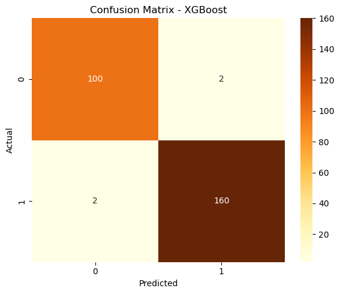

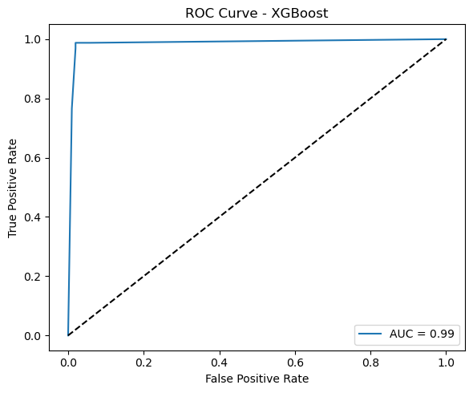

```python
# Load required modules
from xgboost import XGBClassifier, plot_importance
from sklearn.model_selection import GridSearchCV, RepeatedStratifiedKFold
from sklearn.metrics import (classification_report, confusion_matrix,
                             f1_score, precision_score, recall_score, accuracy_score, roc_auc_score, roc_curve)
import matplotlib.pyplot as plt
import seaborn as sns

# Define the parameter grid
param_grid = {
    'n_estimators': [100, 300, 500],
    'max_depth': [3, 5, 7],
    'learning_rate': [0.01, 0.1, 0.3],
    'subsample': [0.8, 1.0],
    'colsample_bytree': [0.8, 1.0],
    'gamma': [0, 1],
    'min_child_weight': [1, 5],
    'scale_pos_weight': [1]
}

# Define cross-validation strategy
cv = RepeatedStratifiedKFold(n_splits=5, n_repeats=2, random_state=42)

# Initialize the model
xgb = XGBClassifier(use_label_encoder=False, eval_metric='logloss', random_state=42)

# Grid Search
grid_search = GridSearchCV(estimator=xgb,
                           param_grid=param_grid,
                           scoring='f1_macro',
                           cv=cv,
                           n_jobs=-1,
                           verbose=1)

# Fit the model
grid_result = grid_search.fit(X_train, y_train)

# Best estimator
best_xgb = grid_result.best_estimator_

# Predict class labels
xgb_pred = best_xgb.predict(X_test)

# Predict probabilities
xgb_prob = best_xgb.predict_proba(X_test)
xgb_score = accuracy_score(y_test, xgb_pred)

# Get probabilities of the positive class (label = 1)
xgb_prob_positive = xgb_prob[:, 1]

# Evaluate performance
print(" Best Hyperparameters:", grid_result.best_params_)
print("\n Classification Report:\n", classification_report(y_test, xgb_pred))
print(" F1 Score (macro):", f1_score(y_test, xgb_pred, average='macro'))
print(" Precision (macro):", precision_score(y_test, xgb_pred, average='macro'))
print(" Recall (macro):", recall_score(y_test, xgb_pred, average='macro'))
print(" Accuracy:", accuracy_score(y_test, xgb_pred))

# Print some of the predicted probabilities
print("\nSample predicted probabilities:\n", xgb_prob[:10])

# Confusion Matrix
plt.figure(figsize=(6, 5))
sns.heatmap(confusion_matrix(y_test, xgb_pred), annot=True, fmt='d', cmap='YlOrBr')
plt.title("Confusion Matrix - XGBoost")
plt.xlabel("Predicted")
plt.ylabel("Actual")
plt.tight_layout()
plt.show()

# ROC Curve
if len(set(y_test)) == 2:
    fpr, tpr, thresholds = roc_curve(y_test, xgb_prob_positive)
    auc_score = roc_auc_score(y_test, xgb_prob_positive)

    plt.figure(figsize=(6, 5))
    plt.plot(fpr, tpr, label=f"AUC = {auc_score:.2f}")
    plt.plot([0, 1], [0, 1], 'k--')
    plt.xlabel("False Positive Rate")
    plt.ylabel("True Positive Rate")
    plt.title("ROC Curve - XGBoost")
    plt.legend(loc="lower right")
    plt.tight_layout()
    plt.show()
```

### K Nearest Neighbors

```
Fitting 30 folds for each of 40 candidates, totalling 1200 fits
Best Hyperparameters:
 {'knn__metric': 'manhattan', 'knn__n_neighbors': 24, 'knn__weights': 'distance'}
Best Cross-Validated F1 Macro Score:
 0.6705433917066951

📊 Classification Report:
               precision    recall  f1-score   support

           0       0.59      0.63      0.61       102
           1       0.76      0.73      0.74       162

    accuracy                           0.69       264
   macro avg       0.67      0.68      0.68       264
weighted avg       0.69      0.69      0.69       264

Accuracy Score: 0.6893939393939394
F1 Score (Macro): 0.6758310871518418
Precision (Macro): 0.6745014245014245
Recall (Macro): 0.677923021060276
```

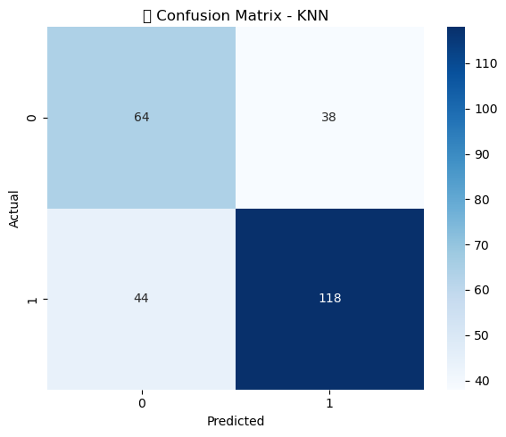

```python
# Load the required libraries
from sklearn.neighbors import KNeighborsClassifier
from sklearn.model_selection import GridSearchCV, RepeatedStratifiedKFold
from sklearn.pipeline import Pipeline
from sklearn.metrics import (
    classification_report, confusion_matrix,
    accuracy_score, f1_score, precision_score, recall_score
)

# Define the pipeline
pipeline = Pipeline([
    ('knn', KNeighborsClassifier())
])

# Define hyperparameters to tune
param_grid = {
    'knn__n_neighbors': range(15, 25),
    'knn__weights': ['uniform', 'distance'],
    'knn__metric': ['euclidean', 'manhattan']
}

# Define cross-validation strategy
cv = RepeatedStratifiedKFold(n_splits=10, n_repeats=3, random_state=42)

## Setup Grid Search
grid_search = GridSearchCV(
    estimator=pipeline,
    param_grid=param_grid,
    n_jobs=-1,
    cv=cv,
    scoring='f1_macro',
    error_score=0,
    verbose=1
)

# Fit the model
best_model = grid_search.fit(X_train, y_train)

# Make predictions
knn_pred = best_model.predict(X_test)
knn_score = accuracy_score(y_test, knn_pred)

# Display best hyperparameters
print("Best Hyperparameters:\n", grid_search.best_params_)
print("Best Cross-Validated F1 Macro Score:\n", grid_search.best_score_)

# Classification metrics
print("\n📊 Classification Report:\n", classification_report(y_test, knn_pred))
print("Accuracy Score:", accuracy_score(y_test, knn_pred))
print("F1 Score (Macro):", f1_score(y_test, knn_pred, average='macro'))
print("Precision (Macro):", precision_score(y_test, knn_pred, average='macro'))
print("Recall (Macro):", recall_score(y_test, knn_pred, average='macro'))

# Confusion matrix plot
cm = confusion_matrix(y_test, knn_pred)
plt.figure(figsize=(6, 5))
sns.heatmap(cm, annot=True, fmt='d', cmap='Blues')
plt.title("🔍 Confusion Matrix - KNN")
plt.xlabel("Predicted")
plt.ylabel("Actual")
plt.tight_layout()
plt.show()
```

### Gradient Boosting Machines

```
Fitting 10 folds for each of 20 candidates, totalling 200 fits
Best Parameters:
 {'subsample': 0.8, 'n_estimators': 100, 'min_samples_split': 5, 'min_samples_leaf': 2, 'max_depth': 5, 'learning_rate': 0.01}
Best CV F1 Score:
 0.9930439894613061

Classification Report:
               precision    recall  f1-score   support

           0       0.98      0.98      0.98       102
           1       0.99      0.99      0.99       162

    accuracy                           0.98       264
   macro avg       0.98      0.98      0.98       264
weighted avg       0.98      0.98      0.98       264

Accuracy Score: 0.9848484848484849
F1 Score: 0.9840232389251997
Precision: 0.9840232389251997
Recall: 0.9840232389251997
```

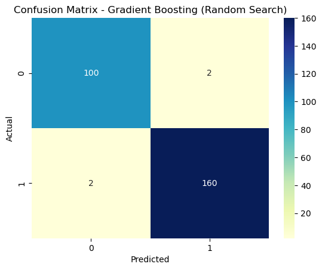

```python
# Import required modules
from sklearn.ensemble import GradientBoostingClassifier
from sklearn.model_selection import RandomizedSearchCV, RepeatedStratifiedKFold
from sklearn.metrics import classification_report, confusion_matrix, accuracy_score, f1_score, precision_score, recall_score
import seaborn as sns
import matplotlib.pyplot as plt
import numpy as np

# Define the model
gbm = GradientBoostingClassifier(random_state=42)

# Define hyperparameter space
param_dist = {
    'n_estimators': np.arange(80, 201, 20),         # 80 to 200 in steps of 20
    'learning_rate': [0.01, 0.03, 0.05, 0.1],
    'max_depth': [3, 4, 5, 6],
    'subsample': [0.6, 0.8, 1.0],
    'min_samples_split': [2, 5, 10],
    'min_samples_leaf': [1, 2, 4]
}

# Cross-validation strategy
cv = RepeatedStratifiedKFold(n_splits=5, n_repeats=2, random_state=42)

# Setup RandomizedSearchCV
random_search = RandomizedSearchCV(estimator=gbm,
                                   param_distributions=param_dist,
                                   n_iter=20,                  # try only 20 random combinations
                                   scoring='f1',
                                   n_jobs=-1,
                                   cv=cv,
                                   verbose=1,
                                   random_state=42)

# Fit the model
best_model = random_search.fit(X_train, y_train)

# Predict on test data
gbm_pred = best_model.predict(X_test)
gbm_score = accuracy_score(y_test, gbm_pred)

# Print best hyperparameters and CV score
print("Best Parameters:\n", random_search.best_params_)
print("Best CV F1 Score:\n", random_search.best_score_)

# Evaluation metrics
print("\nClassification Report:\n", classification_report(y_test, gbm_pred))
print("Accuracy Score:", accuracy_score(y_test, gbm_pred))
print("F1 Score:", f1_score(y_test, gbm_pred, average='macro'))
print("Precision:", precision_score(y_test, gbm_pred, average='macro'))
print("Recall:", recall_score(y_test, gbm_pred, average='macro'))

# Confusion Matrix Plot
cm = confusion_matrix(y_test, gbm_pred)
sns.heatmap(cm, annot=True, fmt='d', cmap='YlGnBu')
plt.title("Confusion Matrix - Gradient Boosting (Random Search)")
plt.xlabel("Predicted")
plt.ylabel("Actual")
plt.show()
```

### Ada Boost Classifier

```
Best Parameters from Grid Search: {'estimator__max_depth': 2, 'learning_rate': 0.01, 'n_estimators': 250}
Cross-validation Accuracy: 0.9880 ± 0.0067

=== Evaluation on Test Set ===
Classification Report:
               precision    recall  f1-score   support

           0       0.98      0.98      0.98       102
           1       0.99      0.99      0.99       162

    accuracy                           0.98       264
   macro avg       0.98      0.98      0.98       264
weighted avg       0.98      0.98      0.98       264

Accuracy: 0.9848484848484849
F1 Score: 0.9840232389251997
Precision: 0.9840232389251997
Recall: 0.9840232389251997
```

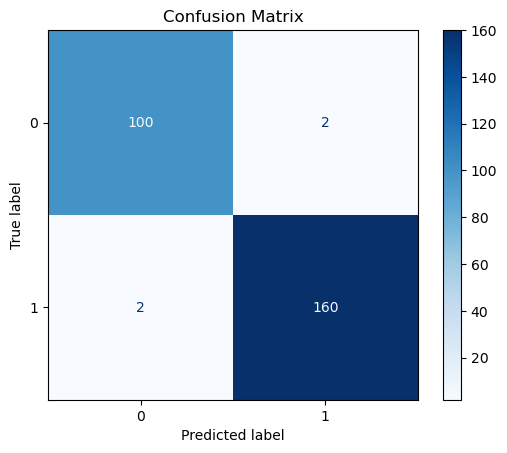

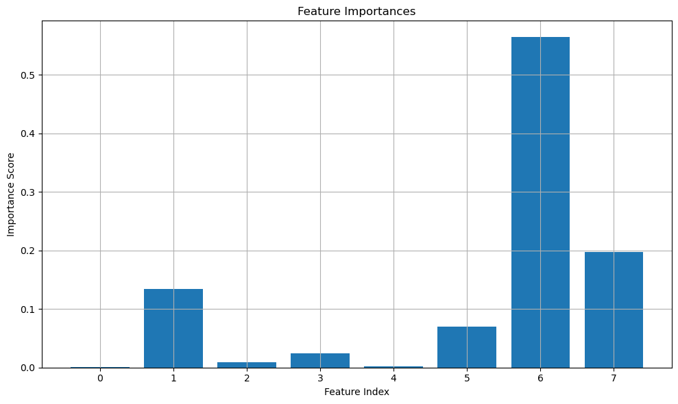

```python
# Import required modules
from sklearn.ensemble import AdaBoostClassifier
from sklearn.tree import DecisionTreeClassifier
from sklearn.model_selection import train_test_split, GridSearchCV, cross_val_score
from sklearn.metrics import (
    accuracy_score,
    classification_report,
    f1_score,
    precision_score,
    recall_score,
    confusion_matrix,
    ConfusionMatrixDisplay
)
import matplotlib.pyplot as plt
import numpy as np

# Define base estimator
base_estimator = DecisionTreeClassifier(max_depth=1)

# Define AdaBoost model
ada = AdaBoostClassifier(estimator=base_estimator, n_estimators=180, learning_rate=1.0)

# Hyperparameter tuning with GridSearchCV
param_grid = {
    'n_estimators': [50, 100, 180, 250],
    'learning_rate': [0.01, 0.1, 1.0],
    'estimator__max_depth': [1, 2, 3]
}

grid_search = GridSearchCV(ada, param_grid, cv=5, scoring='f1_macro', n_jobs=-1)
grid_search.fit(X_train, y_train)

## Best model
best_ada = grid_search.best_estimator_
print("Best Parameters from Grid Search:", grid_search.best_params_)

## Cross-validation scores
cv_scores = cross_val_score(best_ada, X_train, y_train, cv=5, scoring='f1_macro')
print(f"Cross-validation Accuracy: {cv_scores.mean():.4f} ± {cv_scores.std():.4f}")

# Fit model on full training set
best_ada.fit(X_train, y_train)

# Predict on test set
ada_pred = best_ada.predict(X_test)
ada_score = accuracy_score(y_test, ada_pred)

# Evaluate model
print("\n=== Evaluation on Test Set ===")
print("Classification Report:\n", classification_report(y_test, ada_pred))
print("Accuracy:", accuracy_score(y_test, ada_pred))
print("F1 Score:", f1_score(y_test, ada_pred, average='macro'))
print("Precision:", precision_score(y_test, ada_pred, average='macro'))
print("Recall:", recall_score(y_test, ada_pred, average='macro'))

# Confusion Matrix
cm = confusion_matrix(y_test, ada_pred)
disp = ConfusionMatrixDisplay(confusion_matrix=cm)
disp.plot(cmap=plt.cm.Blues)
plt.title("Confusion Matrix")
plt.show()

# Feature Importances
importances = best_ada.feature_importances_
plt.figure(figsize=(10, 6))
plt.bar(np.arange(len(importances)), importances)
plt.title("Feature Importances")
plt.xlabel("Feature Index")
plt.ylabel("Importance Score")
plt.grid(True)
plt.tight_layout()
plt.show()
```

### Voting Classifier

```
Classification Report:
               precision    recall  f1-score   support

           0       0.97      0.98      0.98       102
           1       0.99      0.98      0.98       162

    accuracy                           0.98       264
   macro avg       0.98      0.98      0.98       264
weighted avg       0.98      0.98      0.98       264

Accuracy: 0.9810606060606061
F1 Score: 0.980064939968285
Precision: 0.9792257130796599
Recall: 0.9809368191721133
```

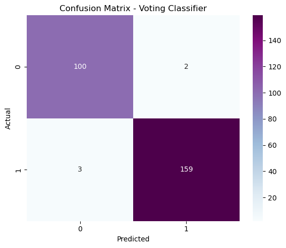

```python
# Load required libraries
from sklearn.ensemble import VotingClassifier, RandomForestClassifier, AdaBoostClassifier
from sklearn.linear_model import LogisticRegression
from sklearn.tree import DecisionTreeClassifier
from sklearn.metrics import (
    classification_report, confusion_matrix,
    accuracy_score, f1_score, precision_score, recall_score
)
from sklearn.model_selection import RepeatedStratifiedKFold

# Define individual base models
log_clf = LogisticRegression(solver='liblinear', random_state=42)
rf_clf = RandomForestClassifier(n_estimators=100, max_depth=5, random_state=42)
ada_clf = AdaBoostClassifier(
    estimator=DecisionTreeClassifier(max_depth=1, random_state=42),
    n_estimators=100,
    learning_rate=0.5,
    random_state=42
)

# Combine them into a Voting Classifier (soft voting)
voting_clf = VotingClassifier(
    estimators=[
        ('lr', log_clf),
        ('rf', rf_clf),
        ('ada', ada_clf)
    ],
    voting='soft',  # soft = uses probabilities
    n_jobs=-1
)

# Fit the model
voting_clf.fit(X_train, y_train)

# Make predictions
vote_pred = voting_clf.predict(X_test)
vote_score = accuracy_score(y_test, vote_pred)

# Evaluate
print("Classification Report:\n", classification_report(y_test, vote_pred))
print("Accuracy:", accuracy_score(y_test, vote_pred))
print("F1 Score:", f1_score(y_test, vote_pred, average='macro'))
print("Precision:", precision_score(y_test, vote_pred, average='macro'))
print("Recall:", recall_score(y_test, vote_pred, average='macro'))

# Confusion matrix
cm = confusion_matrix(y_test, vote_pred)
plt.figure(figsize=(6, 5))
sns.heatmap(cm, annot=True, fmt='d', cmap='BuPu')
plt.title("Confusion Matrix - Voting Classifier")
plt.xlabel("Predicted")
plt.ylabel("Actual")
plt.tight_layout()
plt.show()
```

### Stacking Classifier

```
STACKING MODEL PERFORMANCE
Classification Report:
               precision    recall  f1-score   support

           0       0.98      0.98      0.98       102
           1       0.99      0.99      0.99       162

    accuracy                           0.98       264
   macro avg       0.98      0.98      0.98       264
weighted avg       0.98      0.98      0.98       264

Accuracy: 0.9848484848484849
F1 Score: 0.9840232389251997
Precision: 0.9840232389251997
Recall: 0.9840232389251997
```

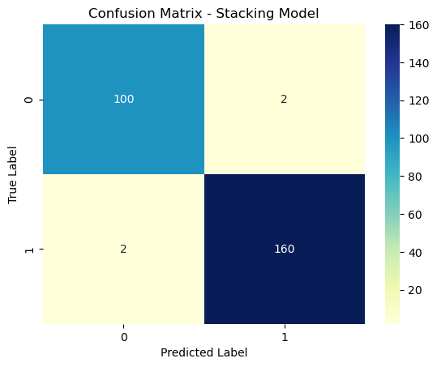

```python
# Import required libraries
from sklearn.ensemble import StackingClassifier
from sklearn.pipeline import Pipeline
from sklearn.model_selection import train_test_split, RepeatedStratifiedKFold
from sklearn.metrics import accuracy_score, classification_report, confusion_matrix, f1_score, precision_score, recall_score

# Define base models
base_learners = [
    ('logreg', LogisticRegression(max_iter=1000)),
    ('dt', DecisionTreeClassifier()),
    ('rf', RandomForestClassifier(n_estimators=100, random_state=42)),
    ('svc', SVC(C=10, kernel='rbf', gamma='scale', probability=True)),  # SVM needs probability=True for stacking
    ('xgb', XGBClassifier(use_label_encoder=False, eval_metric='logloss', random_state=42)),
    ('knn', KNeighborsClassifier(n_neighbors=5)),
]

# Define the meta-model
meta_learner = LogisticRegression()

# Define the stacking classifier
stack_model = StackingClassifier(
    estimators=base_learners,
    final_estimator=meta_learner,
    cv=5,
    n_jobs=-1,
    passthrough=False
)

# Fit the model
stack_model.fit(X_train, y_train)

# Make predictions
y_pred = stack_model.predict(X_test)
stack_score = accuracy_score(y_test, y_pred)

# Evaluate performance
print("STACKING MODEL PERFORMANCE")
print("Classification Report:\n", classification_report(y_test, y_pred))
print("Accuracy:", accuracy_score(y_test, y_pred))
print("F1 Score:", f1_score(y_test, y_pred, average='macro'))
print("Precision:", precision_score(y_test, y_pred, average='macro'))
print("Recall:", recall_score(y_test, y_pred, average='macro'))

# Confusion Matrix
sns.heatmap(confusion_matrix(y_test, y_pred), annot=True, fmt='d', cmap='YlGnBu')
plt.title("Confusion Matrix - Stacking Model")
plt.xlabel("Predicted Label")
plt.ylabel("True Label")
plt.show()
```

### Stochastic Gradient Descent

```
Fitting 10 folds for each of 20 candidates, totalling 200 fits
Best Parameters: {'alpha': 0.0001, 'loss': 'log_loss', 'penalty': 'l1'}
Best CV F1 Macro Score: 0.7523741862801936

📊 Classification Report:
               precision    recall  f1-score   support

           0       0.76      0.76      0.76       102
           1       0.85      0.85      0.85       162

    accuracy                           0.81       264
   macro avg       0.80      0.81      0.80       264
weighted avg       0.81      0.81      0.81       264

Accuracy: 0.8143939393939394
F1 Score (Macro): 0.8046364116891943
Precision (Macro): 0.8041066152083459
Recall (Macro): 0.8051924473493101
```

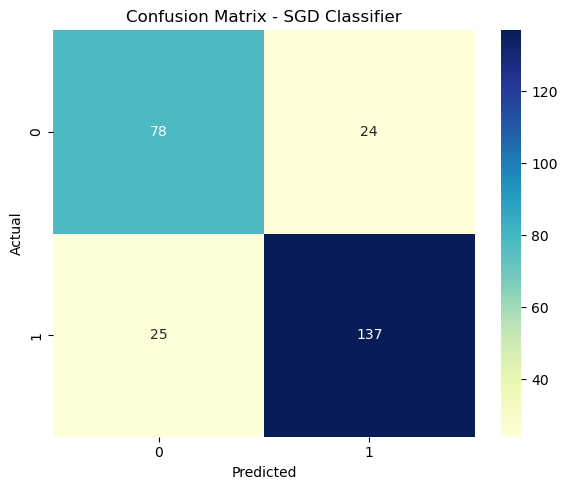

```python
# Load the required modules
from sklearn.linear_model import SGDClassifier
from sklearn.model_selection import GridSearchCV
from sklearn.metrics import (
    classification_report, confusion_matrix,
    accuracy_score, f1_score, precision_score, recall_score
)

# Initialize the model
sgd = SGDClassifier(random_state=42)

# Define the parameters to tune
param_grid = {
    'alpha': [0.0001, 0.001, 0.01, 0.1, 1],
    'loss': ['hinge', 'log_loss'],  # 'log_loss' for logistic regression
    'penalty': ['l1', 'l2']
}

# Setup Grid Search
grid_search = GridSearchCV(estimator=sgd,
                           param_grid=param_grid,
                           cv=10,
                           scoring='f1_macro',  # Better for multi-class or imbalanced data
                           n_jobs=-1,
                           verbose=1)

# Fit the model
grid_search.fit(X_train, y_train)

# Make Predictions
sgd_pred = grid_search.predict(X_test)
sgd_score = accuracy_score(y_test, sgd_pred)

# Best parameters and CV score
print("Best Parameters:", grid_search.best_params_)
print("Best CV F1 Macro Score:", grid_search.best_score_)

# Performance evaluation
print("\n📊 Classification Report:\n", classification_report(y_test, sgd_pred))
print("Accuracy:", accuracy_score(y_test, sgd_pred))
print("F1 Score (Macro):", f1_score(y_test, sgd_pred, average='macro'))
print("Precision (Macro):", precision_score(y_test, sgd_pred, average='macro'))
print("Recall (Macro):", recall_score(y_test, sgd_pred, average='macro'))

# Confusion Matrix
cm = confusion_matrix(y_test, sgd_pred)
plt.figure(figsize=(6, 5))
sns.heatmap(cm, annot=True, fmt='d', cmap='YlGnBu')
plt.title("Confusion Matrix - SGD Classifier")
plt.xlabel("Predicted")
plt.ylabel("Actual")
plt.tight_layout()
plt.show()
```

### Model Comparison

```python
models = pd.DataFrame({
    'Model': ['Logistic Regression', "Decision Trees", 'Random Forest Classifier', 'SVM', "XG Boost", 'KNN', "Gradient Boosting", "Ada Boost Classifier", 'Voting Classifier', 'Stacking Classifier',
             'Stachastic Gradient Boosting'],
    'Score': [log_score, dt_score, rf_score, svm_score, xgb_score, knn_score, gbm_score, ada_score, vote_score, stack_score, sgd_score]
})

models.sort_values(by = 'Score', ascending = False)
```

|  | Model | Score |
| --- | --- | --- |
| 4 | XG Boost | 0.984848 |
| 6 | Gradient Boosting | 0.984848 |
| 7 | Ada Boost Classifier | 0.984848 |
| 9 | Stacking Classifier | 0.984848 |
| 1 | Decision Trees | 0.981061 |
| 2 | Random Forest Classifier | 0.981061 |
| 8 | Voting Classifier | 0.981061 |
| 10 | Stachastic Gradient Boosting | 0.814394 |
| 3 | SVM | 0.787879 |
| 0 | Logistic Regression | 0.712121 |
| 5 | KNN | 0.689394 |

Best model - XGBoost

### SHAP Values for Deeper Interpretability

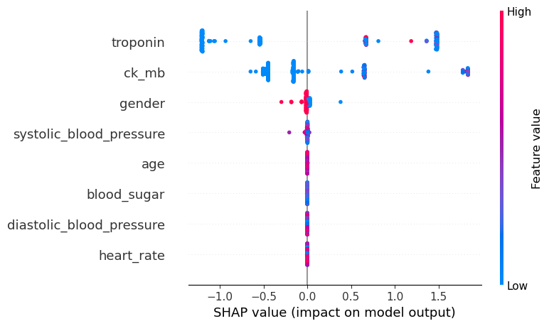

```python
feature_names = [
    'age',
    'gender',
    'heart_rate',
    'systolic_blood_pressure',
    'diastolic_blood_pressure',
    'blood_sugar',
    'ck_mb',
    'troponin'
]

import shap

# Create SHAP explainer for XGBoost
explainer = shap.Explainer(best_xgb)

# Compute SHAP values
shap_values = explainer(X_test)

# Plot SHAP summary (global feature importance)
shap.summary_plot(shap_values, X_test, feature_names=feature_names)
```

### Bar Chart

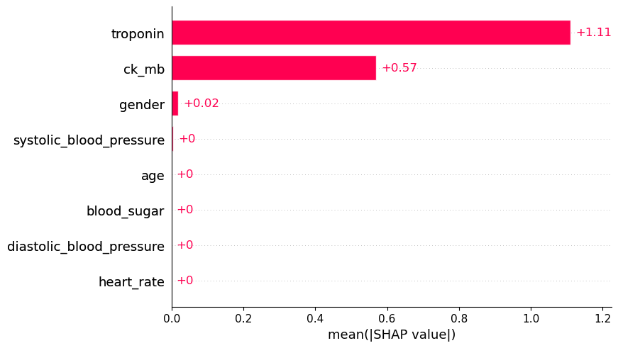

```python
import pandas as pd
import shap

# Step 1: Define feature names
feature_names = [
    'age',
    'gender',
    'heart_rate',
    'systolic_blood_pressure',
    'diastolic_blood_pressure',
    'blood_sugar',
    'ck_mb',
    'troponin'
]

# Step 2: Convert X_test to a DataFrame with column names
X_test_df = pd.DataFrame(X_test, columns=feature_names)

# Step 3: Create SHAP explainer and compute values
explainer = shap.Explainer(best_xgb)
shap_values = explainer(X_test_df)

# Step 4: Plot SHAP bar chart with proper feature names
shap.plots.bar(shap_values, max_display=8)
```

```python
# Save the best model to a file
import pickle
with open('heart_attack_xgb_model.pkl', 'wb') as f:
    pickle.dump(best_xgb, f)
```